# Aula 10 - Mapeamento de QTLs IV Mapeamento por Intervalo Composto; F1 segregante

Letícia Lara e Marianella Quezada

18-06-2015

Considere o conjunto de dados de Mimulus, já usado em aulas anteriores. Usando o mapa que você construiu anteriormente com o OneMap, faça mapeamento por intervalo e por intervalo composto para localizar QTL’s para uma das características presentes no conjunto de dados (escolha a que julgar mais interessante).

- Determine o limiar para rejeitar H0 e apresente os resultados de forma gráfica e em tabelas de forma semelhante aos artigos publicados na área.
- Use o software R/qtl, verificando no tutorial do OneMap como exportar o mapa construído para o formato do R/qtl. Use o Fórum para resolver suas dúvidas.
- O exercício pode ser feito em grupo, pela mesma equipe que fez o mapa genético.
- Apresente os resultados em um arquivo html, da mesma forma que para o mapa de Mimulus.

## Carregando os dados e instalando pacotes

```r
load("lista6.Rdata")

library("ggplot2")
library("onemap")
library("qtl")
library("car")
```

## Leitura de dados

Inicialmemte, o mapa construido no software Onemap será exportado para o software R/qtl.

```r
write.map(mapa, "mimulus.map")  # arquivo do mapa - mapfile

raw.file <- paste(system.file("example", package="onemap"), "mimulus.raw", sep="/")

meus_dados <- read.cross("mm", file=raw.file, mapfile="mimulus.map")
```

```
##  --Read the following data:
##  Type of cross:          f2
##  Number of individuals:  287
##  Number of markers:      418
##  Number of phenotypes:   16
##  --Cross type: f2
```

```r
summary(meus_dados)
```

```
##     F2 intercross
##
##     No. individuals:    287
##
##     No. phenotypes:     16
##     Percent phenotyped: 96.2 93.4 96.2 93 95.8 87.8 96.2 95.8 96.2 96.2
##                         90.2 96.2 95.8 96.2 95.8 96.2
##
##     No. chromosomes:    14
##         Autosomes:      1 2 3 4 5 6 7 8 9 10 11 12 13 14
##
##     Total markers:      398
##     No. markers:        20 21 25 39 21 47 19 32 25 39 26 28 21 35
##     Percent genotyped:  89.4
##     Genotypes (%):      AA:16.4  AB:24.8  BB:22.5  not BB:19.5  not AA:16.8
```

```r
class(meus_dados)
```

```
## [1] "f2"    "cross"
```

Será comparado o mapa construido no Onemap com o mapa re-estimado no R/qtl.

[figure not shown]

```r
plot.map(meus_dados)
```

[figure not shown]

```r
map_rqtl <- est.map(meus_dados, tol=1e-6, map.function="kosambi")

plot.map(meus_dados, map_rqtl)
```

## Dados fenotípicos

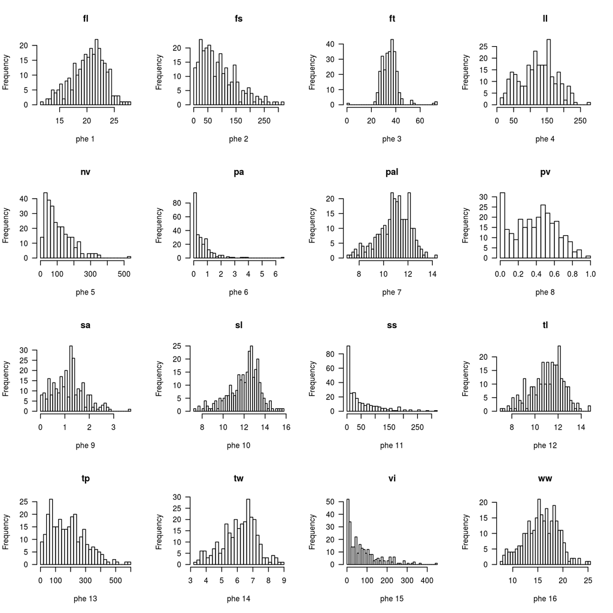

```r
par(mfrow=c(4,4))
for(i in 1:16){
  plot.pheno(meus_dados, pheno.col=i)
  }
```

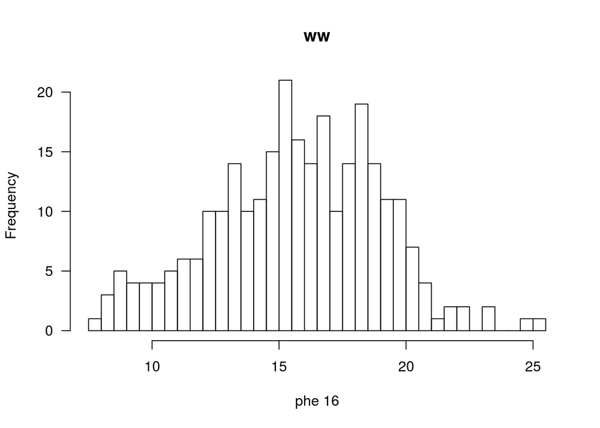

```r
plot.pheno(meus_dados, 16)
```

Considerando o número de dados perdidos e a distribuição no gráfico de frequências, foi selecionado o fenótipo **ww**, com porcentagde dados fenotípicos de 96,2%.

## Informação sobre dados perdidos

Será realizado um análise preliminar da presença de dados perdidos ao longo do genoma, considerando que a fatal de dados genotípicos em algunas regiões pode levar a associações espúrias entre QTLs e marcadores.

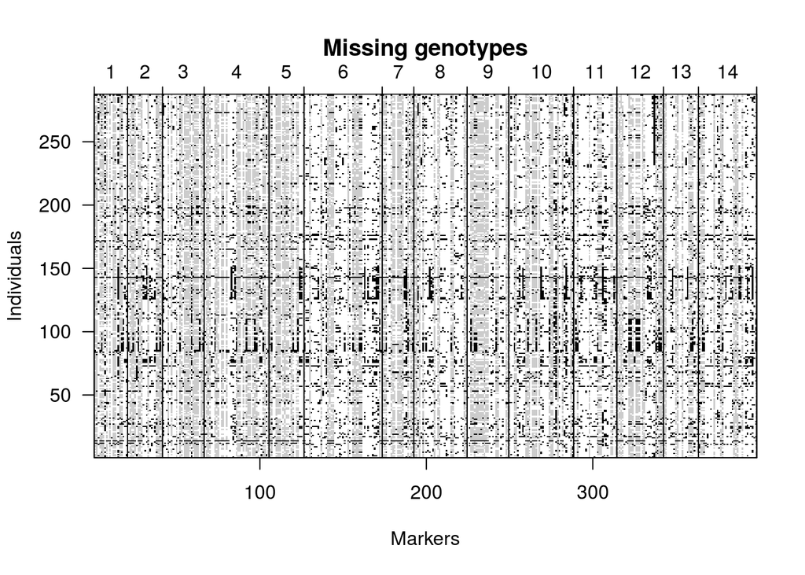

```r
plot.missing (meus_dados)
```

O padrâo de dados perdidos representando no gráfico, mostra em pixeles negros a presença de dados faltantes.

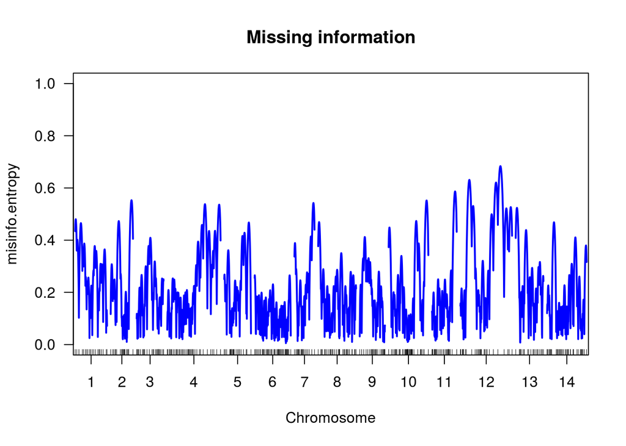

```r
prova <- plot.info (meus_dados, col=c("blue"))
```

```r
head(prova [prova [,1]==7, ], 10)
```

```
##         chr pos misinfo.entropy
## BA220     7   0          0.3371
## c7.loc1   7   1          0.3670
## c7.loc2   7   2          0.3816
## c7.loc3   7   3          0.3883
## c7.loc4   7   4          0.3890
## c7.loc5   7   5          0.3842
## c7.loc6   7   6          0.3741
## c7.loc7   7   7          0.3584
## c7.loc8   7   8          0.3364
## c7.loc9   7   9          0.3063
```

A informação sobre os dados perdidos foi calculada seguindo o conceito de entropia no próprio pacote de R/qtl, a partir da função *plot.info*. Uma razão de zero, indica que contamos com uma completa informação genética, e valores maiores indicam a falta de informação. Para os nossos dados, pode-se verificar valores superiores a 0.5 em algumas posições do genoma.

### Mapeamento por intervalo

Neste primeiro passo será realizado o mapeamento por intervalo (IM) proposto por Lander e Botstein (1989). Este método utiliza o modelo de misturas, no qual são incluídos os genótipos dos QTLs, e análises do tipo multiponto. A função de verossimilhança (assumindo distribuição normal para cada genótipo do QTL) e o algoritmo EM será utilizados para calcular as probabilidades condicionais dos genótipos para qualquer posição do genoma.

```r
prob.cond <- calc.genoprob(meus_dados, step=1, error.prob=0.001)
```

**Valor de thresholds**

Para determinar o limiar para rejeitar H0 será empregado a metodologia de permutações proposta por Churchill e Doerge (1994). Esta metodologia permite estabelecer os valores críticos contra os quais compara o testes estatísticos (LOD score) para detectar QTLs. Uma das vantagens do uso de permutações, é que os valores críticos são obtidos a partir dos próprios dados, e por tanto consideram variáveis próprias do experiment,o como o tamanho da amostra, tamanho do genoma, densidade do mapa genético, número de marcadores, etc.

```r
permut.im <- scanone(prob.cond, pheno.col=16, n.perm=1000, verbose=FALSE, method="em", n.cluster=7)
```

```r
permut.im[1:5]
```

```
##     lod
## 1 2.052
## 2 2.912
## 3 3.070
## 4 2.031
## 5 2.919
## attr(,"class")
## [1] "scanoneperm"
## attr(,"df")
## A
## 2
```

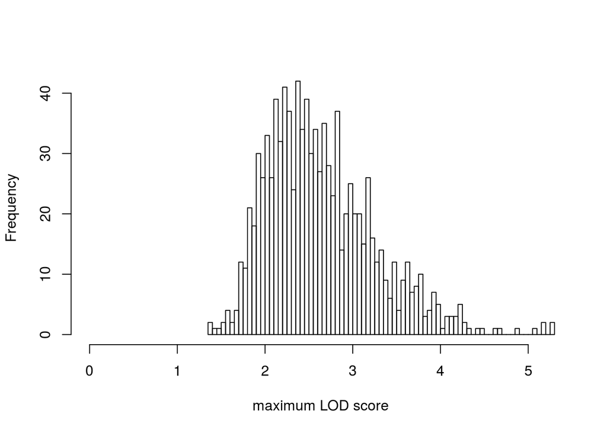

```r
plot(permut.im)
```

```r
summary(permut.im, alpha=0.05)
```

[output not shown]

Pelo comando *plot(permut.im)*, pode-se verificar as distribuições de LOD, sobre a hipótese nula de nenhum QTL. O valor crítico obtido a partir desta distribuição, considerando um percentil de 95%, foi de 3,79.

**Detecção de QTLs**

Será empregada a metodologia de mapeamento por intervalo empregando o algoritmo EM.

```r
mapa.im <- scanone(prob.cond, method="em", pheno.col=16)
summary(mapa.im)
```

```
##            chr   pos   lod
## CA174        1  86.2 1.429
## c2.loc49     2  49.0 2.774
## c3.loc97     3  97.0 4.780
## MgSTS455     4 273.3 1.472
## c5.loc12     5  12.0 1.694
## c6.loc45     6  45.0 2.567
## CC330        7 136.8 0.499
## AAT296       8 167.5 2.116
## BB176        9  85.8 1.655
## AAT374      10 125.1 9.027
## c11.loc61   11  61.0 2.693
## c12.loc82   12  82.0 0.666
## MgSTS622    13 132.7 1.419
## c14.loc168  14 168.0 2.679
```

A partir da função *summary()*, pode-se visualizar os maiores valores de LOD em cada cromossomo, bem como as posições referentes à estes valores.

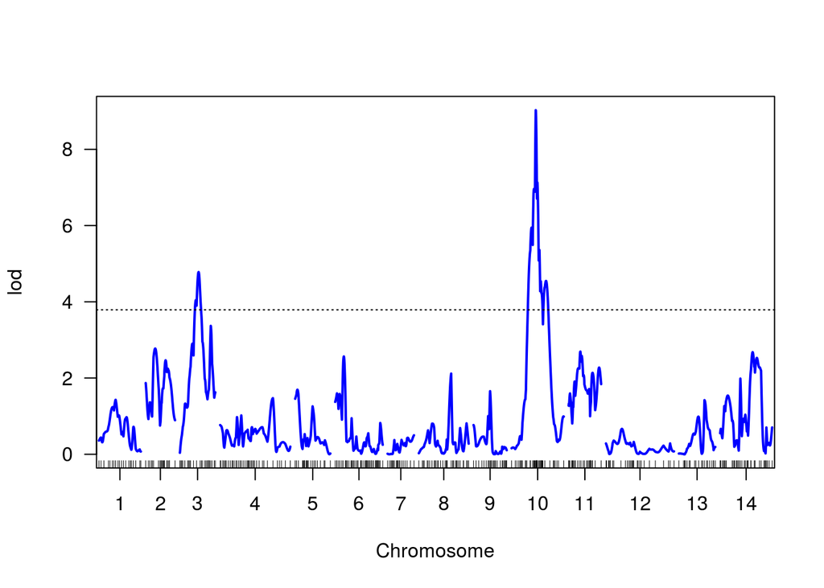

```r
plot(mapa.im, col="blue")
abline(h=3.79, lty=3)
```

**Intervalos dos QTLs**

Para cada QTL detectado são calculados os intervalos no qual o valor de LOD está a 1.8 unidades do ponto de LOD máximo. São mostrados os intervalos considerandos os marcadores mais próximos, suas posições e respectivos valores de LOD.

```r
# QTL no cromossomo 3
lodint(mapa.im, chr=3, drop=1.8, expandtomarkers=T)
```

```
##          chr    pos   lod
## AG19       3  70.62 2.593
## c3.loc97   3  97.00 4.780
## BC586C     3 166.90 2.379
```

```r
# QTL no cromossomo 10
lodint(mapa.im, chr=10, drop=1.8, expandtomarkers=T)
```

```
##          chr   pos   lod
## BC498     10 121.1 6.887
## AAT374    10 125.1 9.027
## MgSTS383  10 131.4 6.707
```

**Efeitos dos QTLs**

Cada QTL será indicado pelo marcador mais próximo.

```r
dados_imput <- sim.geno(meus_dados, n.draws=50, error.prob=0.001)

# QTL no cromossomo 3
find.marker(meus_dados, 3, 97.00)
```

```
## [1] "CA238"
```

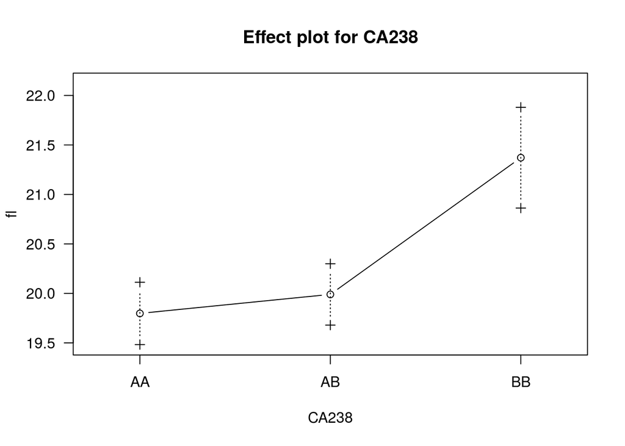

```r
effectplot(dados_imput, mname1="CA238")
```

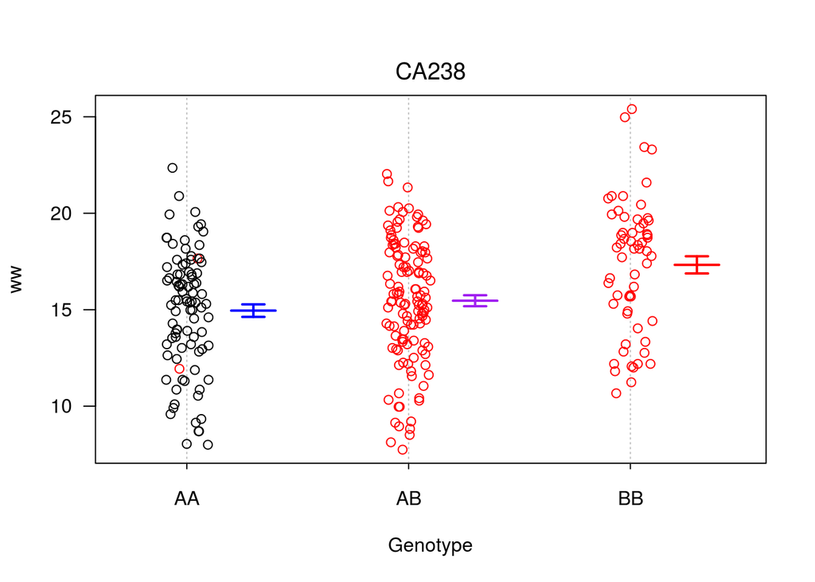

```r
plot.pxg(meus_dados, marker="CA238", pheno.col=16, infer=T)
```

```r
eff3 <- effectplot(dados_imput, mname1="CA238", draw=FALSE)
eff3
```

```
## $Means
## CA238.AA CA238.AB CA238.BB
##    19.80    19.99    21.37
##
## $SEs
## CA238.AA CA238.AB CA238.BB
##   0.3148   0.3099   0.5090
```

```r
# QTL no cromossomo 10
find.marker(meus_dados, 10, 125.0682)
```

```
## [1] "AAT374"
```

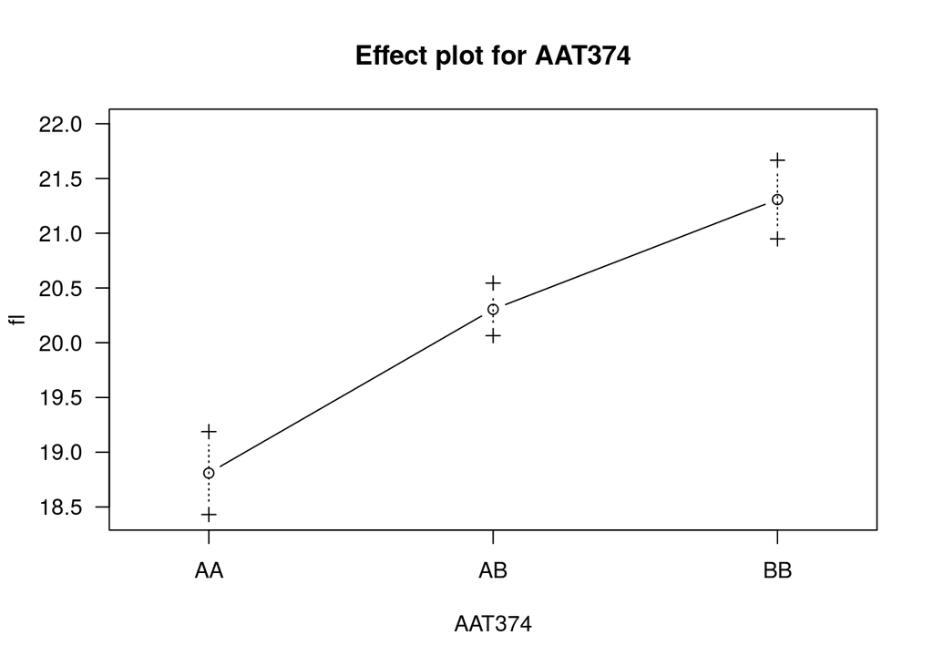

```r
effectplot(efeito10, mname1="AAT374")
```

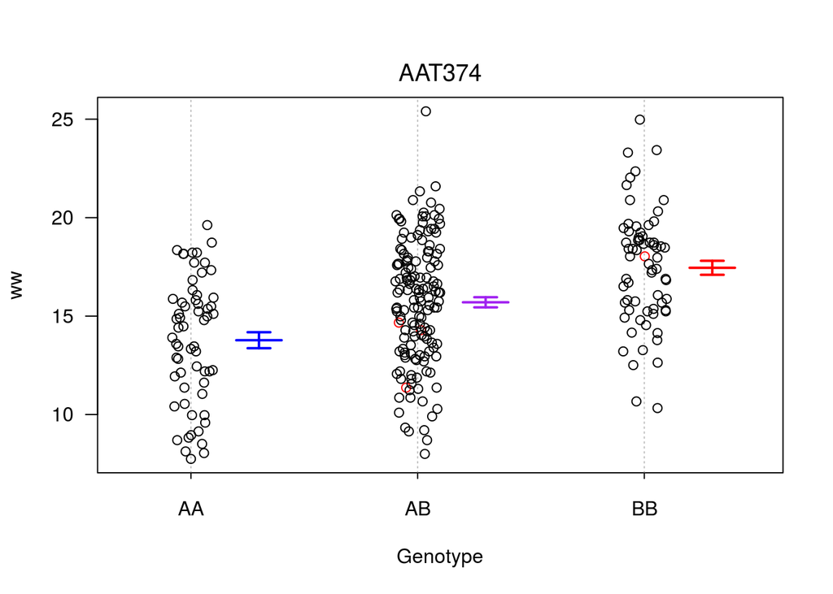

```r
plot.pxg(meus_dados, marker="AAT374", pheno.col=16, infer=T)
```

```r
eff10 <- effectplot(dados_imput, mname1="AAT374", draw=FALSE)
eff10
```

```
## $Means
## AAT374.AA AAT374.AB AAT374.BB
##     18.76     20.31     21.31
##
## $SEs
## AAT374.AA AAT374.AB AAT374.BB
##    0.3857    0.2395    0.3577
```

```r
y <- meus_dados$pheno[,16]
qtl.im <- makeqtl(dados_imput, chr=c(3, 10), pos=c(97.00, 125.0682))

ajuste.im <- fitqtl(dados_imput, qtl=qtl.im, formula= y~Q1+Q2, get.ests=TRUE)
summary(ajuste.im)
```

```
##
##      fitqtl summary
##
## Method: multiple imputation
## Model:  normal phenotype
## Number of observations : 276
##
## Full model result
## ----------------------------------
## Model formula: y ~ Q1 + Q2
##
##        df     SS     MS   LOD  %var Pvalue(Chi2) Pvalue(F)
## Model   4  256.7 64.185 6.327 10.02    7.328e-06 8.932e-06
## Error 271 2305.8  8.508
## Total 275 2562.5
##
##
## Drop one QTL at a time ANOVA table:
## ----------------------------------
##          df Type III SS   LOD  %var F value Pvalue(Chi2) Pvalue(F)
## 3@104.2   2        54.7 1.405 2.135   3.214        0.039    0.0417 *
## 10@125.1  2       186.1 4.653 7.264  10.938        0.000   2.7e-05 ***
## ---
## Signif. codes:  0 '***' 0.001 '**' 0.01 '*' 0.05 '.' 0.1 ' ' 1
##
##
## Estimated effects:
## -----------------
##               est      SE       t
## Intercept 20.2376  0.1793 112.859
## 3@104.2a   0.6341  0.2562   2.475
## 3@104.2d  -0.2887  0.3859  -0.748
## 10@125.1a  1.2246  0.2635   4.648
## 10@125.1d  0.3010  0.3564   0.845
```

Segue abaixo uma tabela com informações dos QTLs identificados pelo mapeamento por intervalo.

| Cromossomo | Marcador | LOD | $r^2$ | Efeito aditivo | Efeito de dominância |
| --- | --- | --- | --- | --- | --- |
| 3 | CA238 | 4.780418 | 1.871 | 0.6037 $\pm$ 0.2649 | -0.2319 $\pm$ 0.4049 |
| 10 | AAT374 | 9.026581 | 6.965 | 1.1988 $\pm$ 0.2662 | 0.2536 $\pm$ 0.3571 |

Como resultado podemos obervar que o QTL no cromossomo 10 apresenta um efeito aditivo maior que o do QTL no cromossomo 3, para a caraterística fenotípica avaliada **ww**. Para o caso dos efeitos de dominância, pode-se observar que os QTls possuem efeitos opostos, sendo um positivo e outro negativo.

Abaixo será apresentado o mapa genético indicando a posições dos dois QTLs detectados.

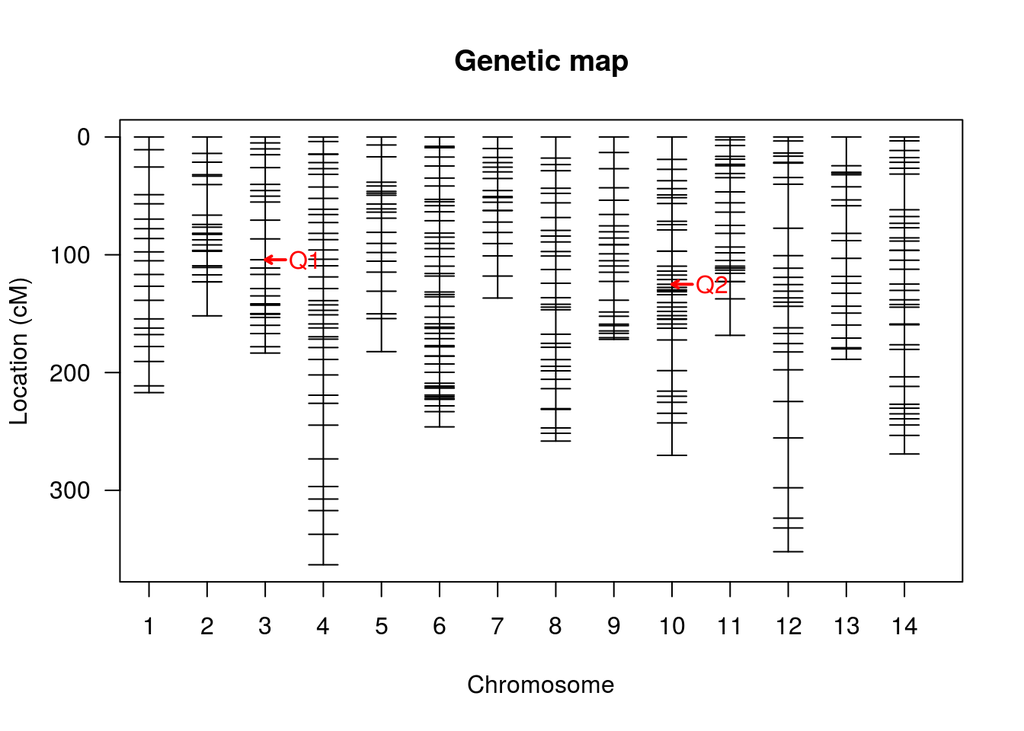

```r
plot(qtl.im)
```

### Mapeamento por intervalo composto

O mapeamento por intervalo composto consiste basicamente numa combinação entre o mapeamento por intervalo e a regressão múltipla (Zeng, 1994). Este modelo envolve tanto o QTL dentro de um intervalo quanto locos marcadores fora deste intervalo (cofatores ou covariáveis). A inferência é feita por máxima verossimilhança. Outros QTLs afetando a característica podem estar espalhados pelo genoma, sendo seus efeitos removidos por regressões de marcadores fora do intervalo.

**Valor de thresholds**

Novamente serão permutados os valores fenotípicos das amostra para estimar o valor crítico de LOD.

```r
permut.cim <- cim(prob.cond, pheno.col=16, n.marcovar=10, window=20, n.perm=1000, method="em")
```

```r
permut.cim[1:5]
```

```
##       [,1]
## [1,] 2.822
## [2,] 4.216
## [3,] 3.203
## [4,] 4.893
## [5,] 5.990
## attr(,"class")
## [1] "scanoneperm" "matrix"
```

```r
summary(permut.cim, alpha=0.05)
```

```
## LOD thresholds (1000 permutations)
##    [,1]
## 5% 6.19
```

O valor crítico obtido a partir desta distribuição, considerando um percentil de 95%, foi de 6,19.

**Detecção de QTLs**

A aproximação realizada pela função *cim()* utiliza uma seleção *forward* de um número fixo de marcadores (definido pelo argumento *n.marcovar*), seguido pelo mapeamento por intervalo, omitindo quaisquer covariáveis dentro de alguma distância fixada com o argumento *window* (no valor de *window* representa o valor total do intervalo).

```r
mapa.cim <- cim(prob.cond, pheno.col=16, n.marcovar=10, window=20, method="em")
summary(mapa.cim)
```

```
##            chr   pos   lod
## BA129        1 105.1 1.338
## BD99         2 123.0 2.044
## c3.loc107    3 107.0 4.490
## c4.loc89     4  89.0 2.652
## c5.loc88     5  88.0 2.143
## c6.loc48     6  48.0 0.749
## CB162        7  35.2 1.740
## MgSTS537     8 247.0 0.785
## BB176        9  85.8 1.281
## AAT374      10 125.1 9.704
## c11.loc156  11 156.0 2.215
## c12.loc12   12  12.0 0.939
## MgSTS55     13 103.0 1.659
## c14.loc169  14 169.0 2.644
```

A partir da função *summary()*, pode-se visualizar os maiores valores de LOD em cada cromossomo, bem como as posições referentes à estes valores.

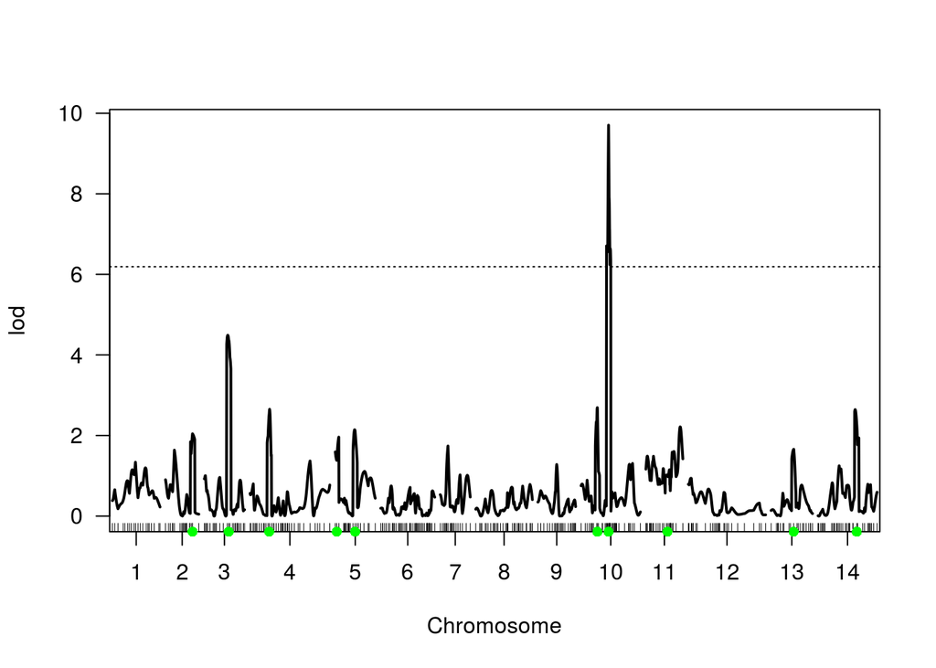

```r
plot(mapa.cim)
add.cim.covar(mapa.cim, col="green")
abline(h=6.19, lty=3)
```

**Intervalos dos QTLs**

```r
# QTL no cromossomo 10
lodint(mapa.cim, chr=10, drop=1.8, expandtomarkers=T)
```

```
##        chr   pos   lod
## BC498   10 121.1 6.561
## AAT374  10 125.1 9.704
## BB122   10 127.7 7.877
```

O QTL detectado está na mesma posição que quando utilizado o método de mapeamento por intervalo.

**Efeitos dos QTLs**

```r
# QTL no cromossomo 10
find.marker(meus_dados, 10, 125.0682)
```

```
## [1] "AAT374"
```

Para o QTL no cromossomo 10, o marcador mais próximo foi o mesmo que o obtido no mapeamento por intervalo.

```r
eff10
```

```
## $Means
## AAT374.AA AAT374.AB AAT374.BB
##     18.76     20.31     21.31
##
## $SEs
## AAT374.AA AAT374.AB AAT374.BB
##    0.3857    0.2395    0.3577
```

```r
qtl.cim <- makeqtl(dados_imput, chr=c(10), pos=c(125.0682))

ajuste.cim <- fitqtl(dados_imput, qtl=qtl.cim, formula= y~Q1, get.ests=TRUE)
summary(ajuste.cim)
```

```
##
##      fitqtl summary
##
## Method: multiple imputation
## Model:  normal phenotype
## Number of observations : 276
##
## Full model result
## ----------------------------------
## Model formula: y ~ Q1
##
##        df   SS      MS   LOD  %var Pvalue(Chi2) Pvalue(F)
## Model   2  202 101.021 4.922 7.885    1.196e-05 1.353e-05
## Error 273 2360   8.646
## Total 275 2562
##
##
## Estimated effects:
## -----------------
##               est      SE       t
## Intercept 20.1736  0.1780 113.357
## 10@125.1a  1.2671  0.2637   4.805
## 10@125.1d  0.2718  0.3583   0.759
```

Segue abaixo uma tabela com informação do QTL identificado pelo mapeamento por intervalo composto.

[output not shown]

Abaixo será apresentado o mapa genético indicando a posição deste QTL.

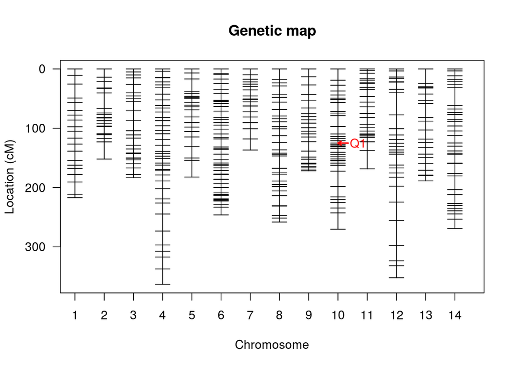

```r
plot(qtl.cim)
```

### Comparação dos métodos

Serão comparados os resultados obtidos com ambas metodologias.

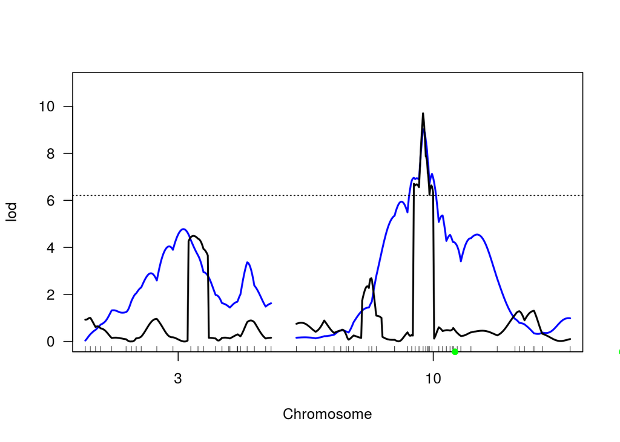

[output not shown]

```r
plot(mapa.im, col="blue", chr=c(3,10), ylim=c(0, 11))
plot(mapa.cim, col="black", add=TRUE, chr=c(3,10))
add.cim.covar(mapa.cim, col="green")
abline(h=6.21, lty=3)
```

Como demostrado na tabela, houve diferenças nos resultados obtidos entre as duas metodologias. No método IM foram detectados dois QTls, nos cromossomos 3 e 10, mas para o método CIM foi detectado apenas um QTL no cromossomo 10 (considerando em ambos casos o valor critico obtido com o procedimento de permutações). Pode-se ainda verificar que o QTL detectado no cromossomo 10 é o mesmo para ambos métodos (marcador AAT374), com a mesma posição (125,0682), porém com maior valor de LOD e menor amplitude no método CIM.

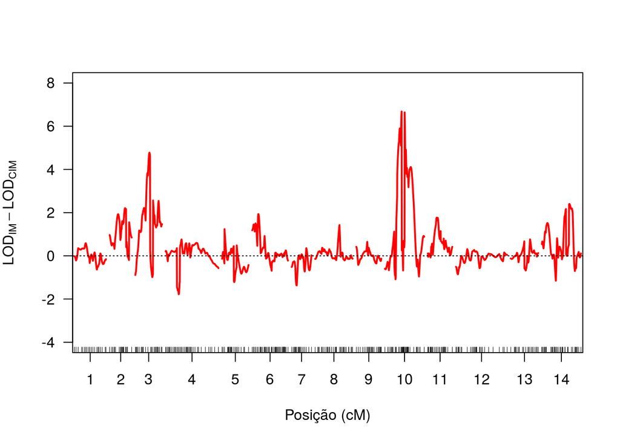

```r
plot (mapa.im - mapa.cim, ylim=c(-4, 8), ylab= expression (LOD[IM] - LOD [CIM]), xlab= "Posição (cM)", col="red")
abline (h=0, lty=3)
```

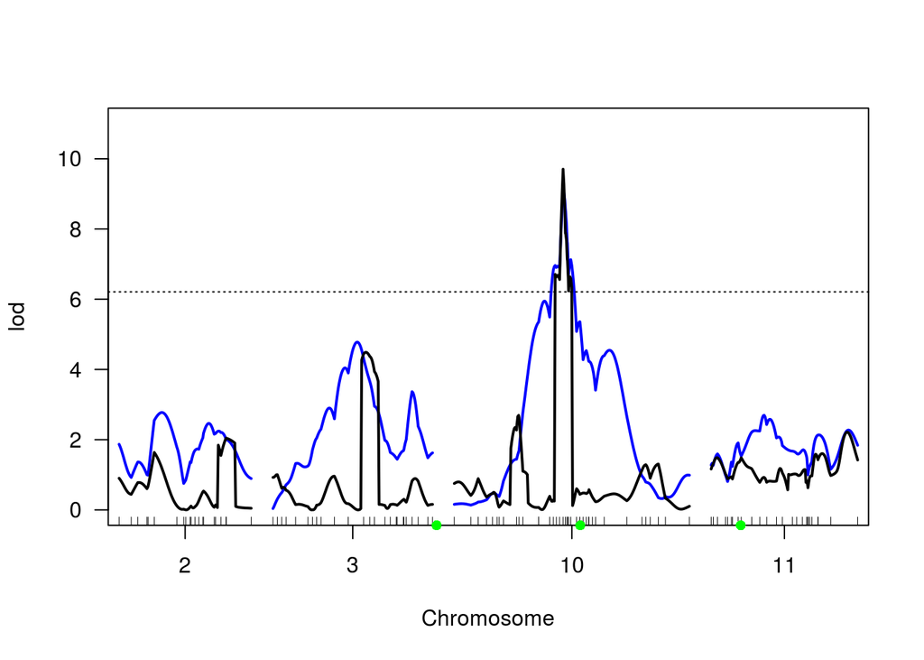

```r
plot(mapa.im, col="blue", chr=c(2,3,10,11), ylim=c(0, 11))
plot(mapa.cim, col="black", add=TRUE, chr=c(2,3,10,11))
add.cim.covar(mapa.cim, col="green")
abline(h=6.21, lty=3)
```

Outras alternativas para estabelecer os valor crítico seria o uso de um valor fixo para cada espécie (método analítico) ou por simulações. No momento de deteção dos QTLs também é fundamental considerar outros aspectos como, o caráter fenotípico avaliado, informação disponível na literatura sobre QTLs nesta espécie, o objetivo final da pesquisa realizada e a experiência do pesquisador.

Embora nossos resultados sugerem presença de QTLs apenas no cromossomo 10 (método CIM), investigações nos cromossomos 2, 3 e 11, com uma análise menos conservativa, torna-se de suma importância para a detecção de possíveis QTLs em *Mimulus*.

### Referências Bibliográficas

G.A. Churchill, R.W. Doerge, Empirical Threshold Values for Quantitative Trait Mapping, Genetics. 138 (1994) 963-971.

E.S. Lander, D. Botstein, Mapping Mendelian Factors Underlying Quantitative Traits Using RFLP Linkage Maps, Genetics. 121 (1989) 185-199.

Z. Zeng, Precision Mapping of Quantitative Trait Loci, Genetics. 1136 (1994) 1457-1468.

```r
save.image("lista10.Rdata")
```